# Lab Meeting Demo – Data Visualization: `ggplot` part 4

## Lab meeting goals

- solicit feed back & ideas on how to introduce these concepts to people with non-begginer familiarity with the topic
- solicit content ideas and general knowledge
  - what r markdown features do you know and love?
  - if you recall, what are things you wish you’d learned about earlier?

## Resources

- [ggplot2 cheatsheet](https://www.rstudio.com/wp-content/uploads/2015/03/ggplot2-cheatsheet.pdf)
- [R for Data Science](https://r4ds.had.co.nz/)
- [R Cookbook](http://www.cookbook-r.com/)
- [`ggplot` themes](https://ggplot2.tidyverse.org/reference/ggtheme.html)
- [Rebecca Barter `ggplot` Tutorial](http://www.rebeccabarter.com/blog/2017-11-17-ggplot2_tutorial/)
- [R Color Brewer](http://colorbrewer2.org/#type=sequential&scheme=BuGn&n=3)

## Install `RColorBrewer`, `paletteer`, and `ggthemes`

`RColorBrewer` and `paletteer` are helpful in selecting palettes of color that work with your data.

```r
#install.packages("RColorBrewer")
#install.packages("paletteer")
#install.packages("ggthemes")
```

## Load the libraries

```r
library(tidyverse)
library(RColorBrewer)
library(paletteer)
library(janitor)
library(here)
```

```r
options(scipen=999) #cancels the use of scientific notation for the session
```

## Load the libraries

```r
library(tidyverse)
library(here)
library(janitor)
```

## Load the data

Let’s revisit the mammal life history data to practice our ggplot skills. The [data](http://esapubs.org/archive/ecol/E084/093/) are from: *S. K. Morgan Ernest. 2003. Life history characteristics of placental non-volant mammals. Ecology 84:3402.*

```r
life_history <- read_csv(here("data", "mammal_lifehistories_v2.csv")) %>% na_if("-999") %>% clean_names()
```

## Violin Plots

Violin plots show the distribution of continuous data across a categorical variable. Violin plots are similar to box plots and dot plots

lets get an idea of the data structure

```r
life_history %>%
  count(order, sort=T)
```

```
## # A tibble: 17 × 2
##    order              n
##    <chr>          <int>
##  1 Rodentia         665
##  2 Carnivora        197
##  3 Artiodactyla     161
##  4 Primates         156
##  5 Insectivora       91
##  6 Cetacea           55
##  7 Lagomorpha        42
##  8 Xenarthra         20
##  9 Perissodactyla    15
## 10 Macroscelidea     10
## 11 Pholidota          7
## 12 Scandentia         7
## 13 Sirenia            5
## 14 Hyracoidea         4
## 15 Dermoptera         2
## 16 Proboscidea        2
## 17 Tubulidentata      1
```

```r
str(life_history)
```

```
## spec_tbl_df [1,440 × 13] (S3: spec_tbl_df/tbl_df/tbl/data.frame)
##  $ order       : chr [1:1440] "Artiodactyla" "Artiodactyla" "Artiodactyla" "Artiodactyla" ...
##  $ family      : chr [1:1440] "Antilocapridae" "Bovidae" "Bovidae" "Bovidae" ...
##  $ genus       : chr [1:1440] "Antilocapra" "Addax" "Aepyceros" "Alcelaphus" ...
##  $ species     : chr [1:1440] "americana" "nasomaculatus" "melampus" "buselaphus" ...
##  $ mass        : num [1:1440] 45375 182375 41480 150000 28500 ...
##  $ gestation   : num [1:1440] 8.13 9.39 6.35 7.9 6.8 5.08 5.72 5.5 8.93 9.14 ...
##  $ newborn     : num [1:1440] 3246 5480 5093 10167 NA ...
##  $ weaning     : num [1:1440] 3 6.5 5.63 6.5 NA ...
##  $ wean_mass   : num [1:1440] 8900 NA 15900 NA NA ...
##  $ afr         : num [1:1440] 13.5 27.3 16.7 23 NA ...
##  $ max_life    : num [1:1440] 142 308 213 240 NA 251 228 255 300 324 ...
##  $ litter_size : num [1:1440] 1.85 1 1 1 1 1.37 1 1 1 1 ...
##  $ litters_year: num [1:1440] 1 0.99 0.95 NA NA 2 NA 1.89 1 1 ...
##  - attr(*, "spec")=
##   .. cols(
##   ..   order = col_character(),
##   ..   family = col_character(),
##   ..   Genus = col_character(),
##   ..   species = col_character(),
##   ..   mass = col_double(),
##   ..   gestation = col_double(),
##   ..   newborn = col_double(),
##   ..   weaning = col_double(),
##   ..   `wean mass` = col_double(),
##   ..   AFR = col_double(),
##   ..   `max. life` = col_double(),
##   ..   `litter size` = col_double(),
##   ..   `litters/year` = col_double()
##   .. )
##  - attr(*, "problems")=<externalptr>
```

Here, we visualize the distribution of average mass across orders. Since the orders are so diverse in size (an ant v.s. a giraffe), lets use a log function on mass. Also, let’s flip the axes to make the graph more friendly for landscape orientation.

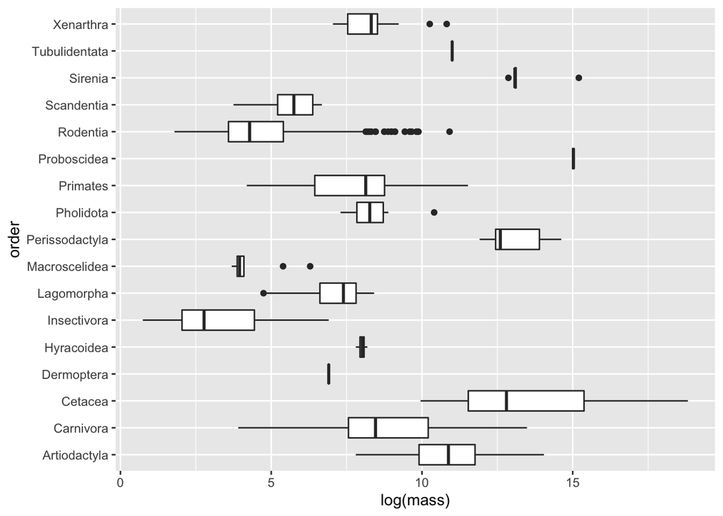

```r
life_history %>%
  ggplot(aes(x = order, y = log(mass))) +
  geom_boxplot(na.rm = TRUE)+
  coord_flip()
```

Let’s focus in on a small set of primates, *Cercopithecidae* family, i.e. Old-world monkeys, and generate a boxplot for each taxonomic genus.

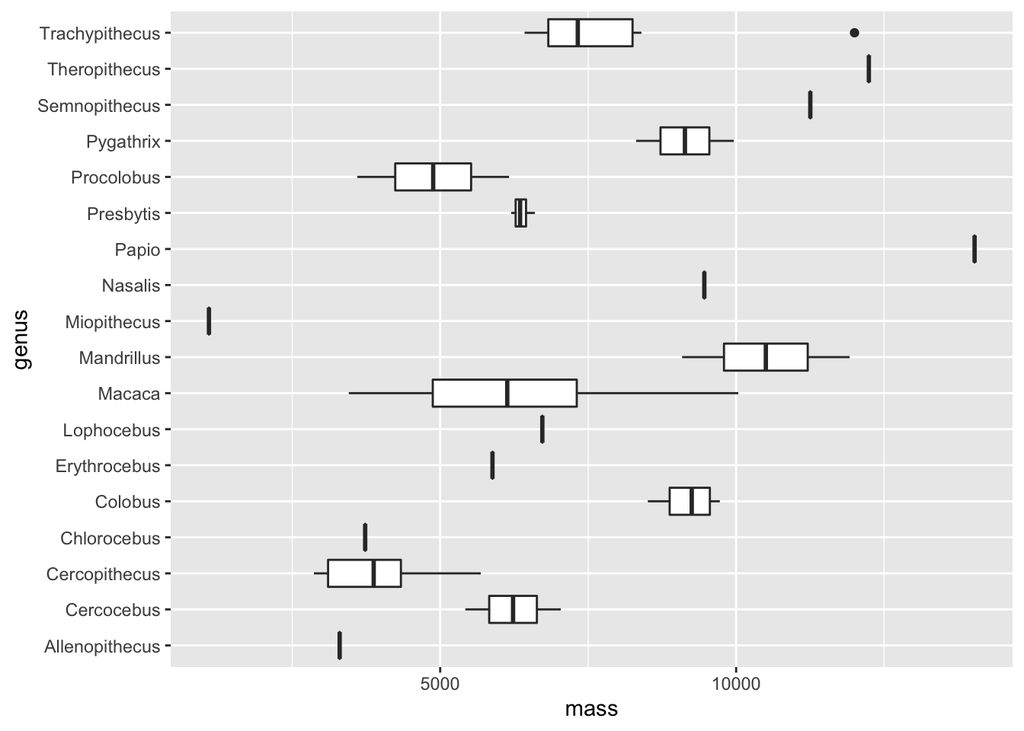

```r
life_history %>%
  filter(family == "Cercopithecidae")%>%
  ggplot(aes(x = genus, y = mass)) +
  geom_boxplot(na.rm = TRUE) +
  coord_flip()
```

Box plots are great at showing median, skew, and outliers. We can visualize skew better by adding a point layer with `geom_point()`

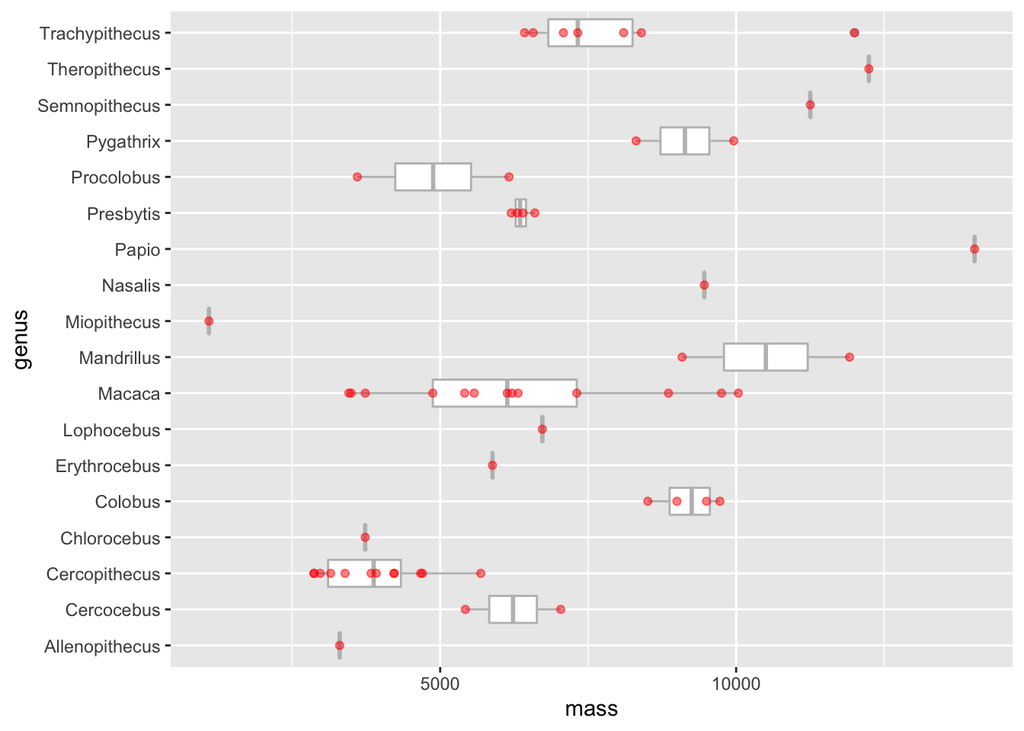

```r
life_history %>%
    filter(family == "Cercopithecidae")%>%
    ggplot(aes(x = genus, y = mass)) +
    geom_boxplot(color = "grey", na.rm = TRUE) +
    geom_point(alpha = 0.5, color = "red", na.rm = TRUE) + #alpha indicates transparency
    coord_flip()
```

By using the geom_point() layer, we see that there are only a few observations for each group (genus). Lets further zoom in on 3 genera of monkey: Macaca, Cercopithecus, and Trachypithecus

we can use violin plots to visualize the distribution of these points on another axis:

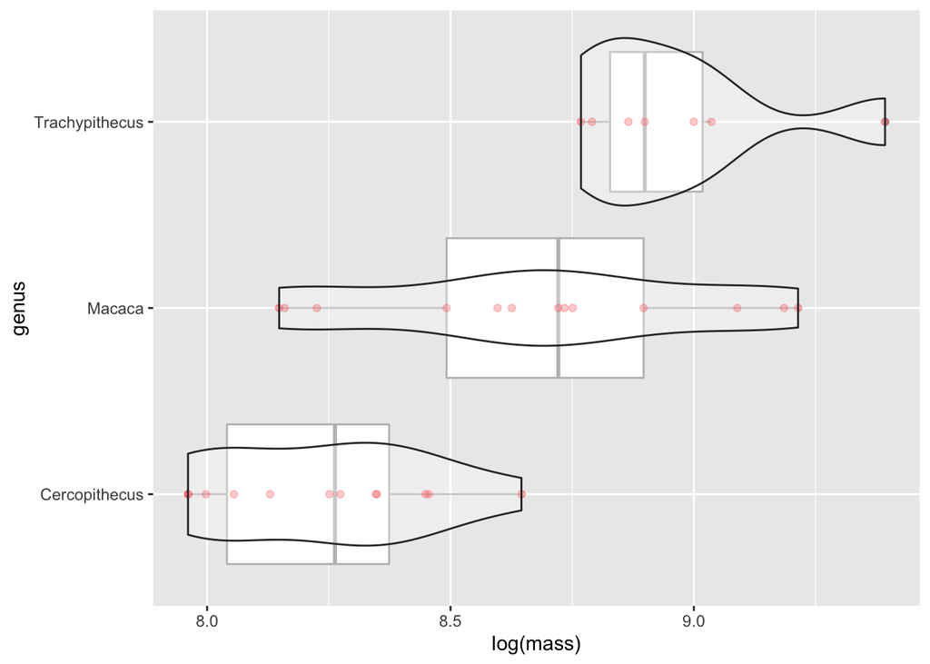

```r
life_history %>%
  filter(genus == "Macaca" | genus == "Cercopithecus"| genus == "Trachypithecus")%>%
  ggplot(aes(x = genus, y = log(mass))) +
  geom_boxplot(color = "grey", na.rm = TRUE) +
  geom_point(alpha = 0.3, color = "red", na.rm = TRUE) + #alpha indicates transparency
  geom_violin(alpha = .3, na.rm = TRUE) +
  coord_flip()
```

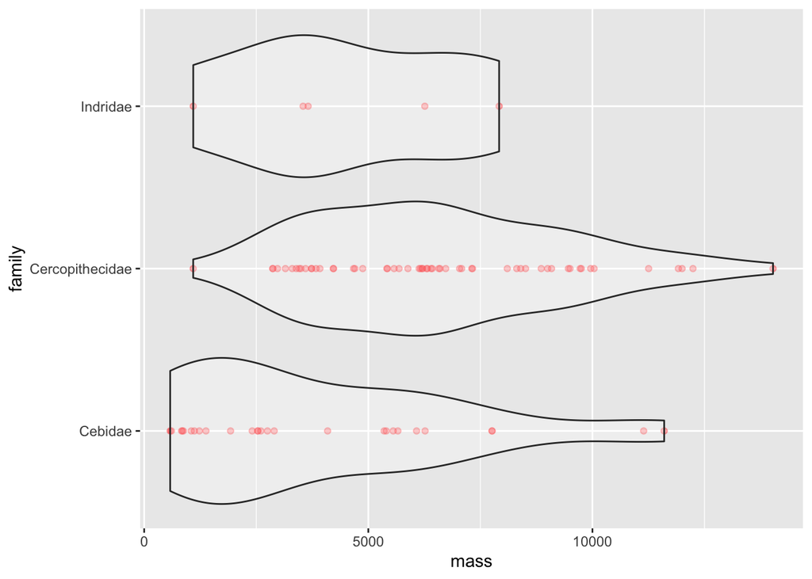

```r
life_history %>%
  filter(family == "Cercopithecidae" | family == "Indridae" | family == "Cebidae") %>%
  ggplot(aes(x = family, y = mass)) +
  geom_point(alpha = 0.3, color = "red", na.rm = TRUE) + #alpha indicates transparency
  geom_violin(alpha = .3, na.rm = TRUE) +
  coord_flip()
```

we can use violin plots to visualize the distribution of these points on another axis:

by default, the violin plot height is based on normalized area. we can switch to count with:

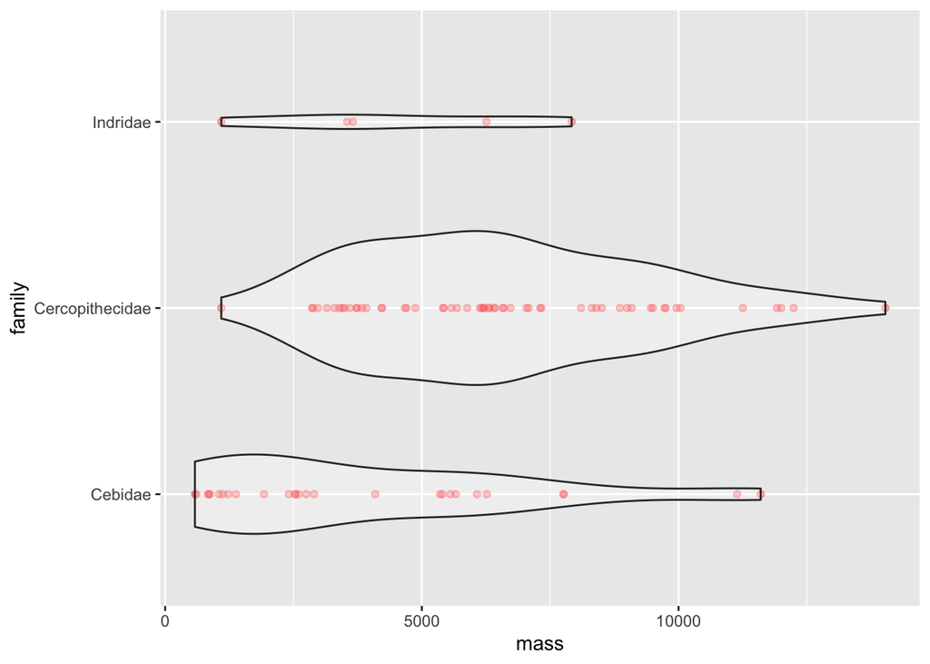

```r
life_history %>%
  filter(family == "Cercopithecidae" | family == "Indridae" | family == "Cebidae") %>%
  ggplot(aes(x = family, y = mass)) +
  geom_point(alpha = 0.3, color = "red", na.rm = TRUE) + #alpha indicates transparency
  geom_violin(scale = "count", alpha = .3, na.rm = TRUE) +
  coord_flip()
```

## Heat maps

[heat maps](https://www.r-graph-gallery.com/79-levelplot-with-ggplot2.html) are a great tool for visualizing data across 2 categorical variables.

## Example 1: column names are data

The following data show results from a drug trial with four treatments on six patients. The values represent resting heart rate.

```r
heartrate <- readr::read_csv("data/heartrate.csv")
heartrate
```

```
## # A tibble: 6 × 5
##   patient      a     b     c     d
##   <chr>    <dbl> <dbl> <dbl> <dbl>
## 1 Margaret    72    74    80    68
## 2 Frank       84    84    88    76
## 3 Hawkeye     64    66    68    64
## 4 Trapper     60    58    64    58
## 5 Radar       74    72    78    70
## 6 Henry       88    87    88    72
```

Let’s pivot this data, so there is no data stored in variables

```r
heartrate_long <- heartrate %>%
  pivot_longer(-patient, #patient does not pivot
               names_to = "drug",
               values_to = "heartrate"
               )
heartrate_long
```

```
## # A tibble: 24 × 3
##    patient  drug  heartrate
##    <chr>    <chr>     <dbl>
##  1 Margaret a            72
##  2 Margaret b            74
##  3 Margaret c            80
##  4 Margaret d            68
##  5 Frank    a            84
##  6 Frank    b            84
##  7 Frank    c            88
##  8 Frank    d            76
##  9 Hawkeye  a            64
## 10 Hawkeye  b            66
## # … with 14 more rows
```

Now we can use `geom_tile()` to represent the contents

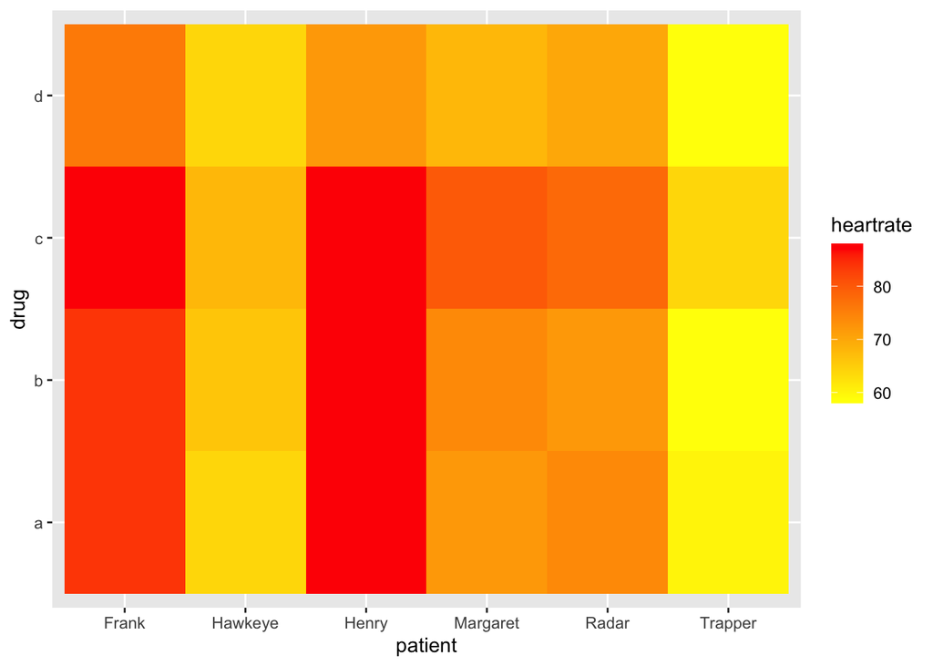

```r
heartrate_long %>%
  ggplot(aes(patient, drug, fill= heartrate)) +
  geom_tile() +
  scale_fill_gradient(low="yellow", high="red")
```

Lets try this on a larger data set. Remember this one from the [United Nations Food and Agriculture Organization](http://www.fao.org/about/en/) on world fisheries? These data are pretty wild, so we need to do some cleaning. First, load the data.

Load the data `FAO_1950to2012_111914.csv` as a new object titled `fisheries`.

```r
fisheries <- readr::read_csv(file = "data/FAO_1950to2012_111914.csv")
```

clean up names,

```r
fisheries <- janitor::clean_names(fisheries)
names(fisheries)
```

```
##  [1] "country"                 "common_name"
##  [3] "isscaap_group_number"    "isscaap_taxonomic_group"
##  [5] "asfis_species_number"    "asfis_species_name"
##  [7] "fao_major_fishing_area"  "measure"
##  [9] "x1950"                   "x1951"
## [11] "x1952"                   "x1953"
## [13] "x1954"                   "x1955"
## [15] "x1956"                   "x1957"
## [17] "x1958"                   "x1959"
## [19] "x1960"                   "x1961"
## [21] "x1962"                   "x1963"
## [23] "x1964"                   "x1965"
## [25] "x1966"                   "x1967"
## [27] "x1968"                   "x1969"
## [29] "x1970"                   "x1971"
```

[output cut: 21 more lines]

lets practice using across() to change some interesting variables to factors

```r
fisheries <-
  fisheries %>% mutate(across(c(country, isscaap_group_number, asfis_species_number, fao_major_fishing_area), as_factor))
```

Notice that these data are in wide format - year (a variable) is represented as columns. Let’s practice pivoting long so we can make a heatmap:

```r
fisheries_long <- fisheries %>%
pivot_longer(cols = starts_with("x"),
               names_to = "year",
               values_to = "catch",
               values_drop_na = TRUE) %>%
  mutate(year= as.numeric(str_replace(year, 'x', ''))) %>%
  mutate(catch= str_replace(catch, c(' F'), replacement = '')) %>%
  mutate(catch= str_replace(catch, c('...'), replacement = '')) %>%
  mutate(catch= str_replace(catch, c('-'), replacement = '')) %>%
  mutate(catch= str_replace(catch, c('0 0'), replacement = ''))

fisheries_long$catch <- as.numeric(fisheries_long$catch)
```

which countries caught a lot of squid in the 90’s?

```r
fisheries_long %>%
  filter(isscaap_taxonomic_group == "Squids, cuttlefishes, octopuses") %>%
  filter(between(year, 1990, 1999)) %>%
  group_by(country) %>%
  summarize(catch_total=sum(catch, na.rm=T)) %>%
  arrange(desc(catch_total))
```

```
## # A tibble: 133 × 2
##    country                  catch_total
##    <fct>                          <dbl>
##  1 Japan                          12718
##  2 Korea, Republic of             11923
##  3 Taiwan Province of China        5583
##  4 Argentina                       4091
##  5 China                           3660
##  6 Mexico                          2965
##  7 Thailand                        2507
##  8 France                          2350
##  9 United States of America        1717
## 10 Spain                           1682
## # … with 123 more rows
```

```r
fish_tycoons <-   fisheries_long%>%
  filter(isscaap_taxonomic_group == "Squids, cuttlefishes, octopuses") %>%
  filter(between(year, 1990, 1999)) %>%
   filter( country == "Japan" |
   country == "Korea, Republic of" |
   country == "Taiwan Province of China" |
  country == "Argentina" |
   country == "China" |
   country == "Mexico"  |
   country == "Thailand" |
   country == "France" |
   country == "United States of America" |
   country == "Spain"
            )%>%
  group_by(country) %>%
  summarize(catch_total=sum(catch, na.rm=T), catch = catch, year = year) %>%
  arrange(desc(catch_total))
```

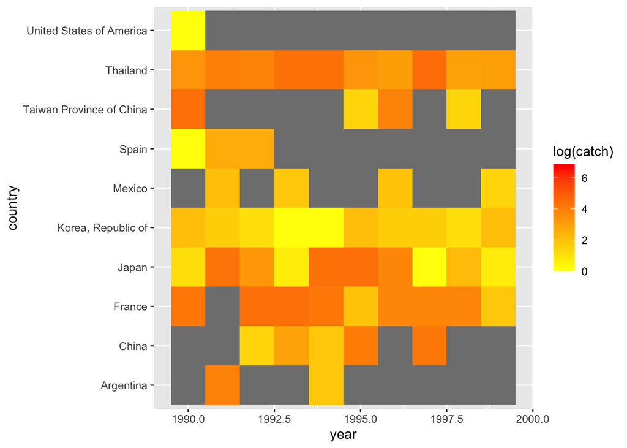

```r
fish_tycoons%>%
  ggplot(aes(x = year, y = country, fill= log(catch))) +
  geom_tile(na.rm = T) +
  scale_fill_gradient(low="yellow", high="red")
```

## Formatting reports: recapping markdown

check out this (source)[https://rmarkdown.rstudio.com/authoring_basics.html] for more

We know about code chunks

```r
names(heartrate_long)
```

```
## [1] "patient"   "drug"      "heartrate"
```

but we can also use back ticks to put a small bit of code in `line with the text`

we can insert hyperlinks into out reports: like (this)[https://en.wikipedia.org/wiki/Hyperlink]